# Risk Factor Analysis

## Outcome Variable

**Outcome Variable:** whz

## Predictor Variables

**Intervention Variable:** hhwealth_quart

**Adjustment Set:**

- arm
- sex
- W_mage
- meducyrs
- feducyrs
- W_gagebrth
- W_birthwt
- W_birthlen
- W_nchldlt5
- W_parity
- delta_W_mage
- delta_meducyrs
- delta_feducyrs
- delta_W_gagebrth
- delta_W_birthwt
- delta_W_birthlen
- delta_W_nchldlt5
- delta_W_parity

## Stratifying Variables

The analysis was stratified on these variable(s):

- agecat
- studyid
- country

## Data Summary

| agecat | studyid | country | hhwealth_quart | n_cell | n |
| --- | --- | --- | --- | --- | --- |
| Birth | CMC-V-BCS-2002 | INDIA | Wealth Q4 | 32 | 86 |
| Birth | CMC-V-BCS-2002 | INDIA | Wealth Q1 | 13 | 86 |
| Birth | CMC-V-BCS-2002 | INDIA | Wealth Q2 | 19 | 86 |
| Birth | CMC-V-BCS-2002 | INDIA | Wealth Q3 | 22 | 86 |
| Birth | COHORTS | GUATEMALA | Wealth Q4 | 258 | 729 |
| Birth | COHORTS | GUATEMALA | Wealth Q1 | 144 | 729 |
| Birth | COHORTS | GUATEMALA | Wealth Q2 | 141 | 729 |
| Birth | COHORTS | GUATEMALA | Wealth Q3 | 186 | 729 |
| Birth | COHORTS | PHILIPPINES | Wealth Q4 | 815 | 2898 |
| Birth | COHORTS | PHILIPPINES | Wealth Q1 | 647 | 2898 |
| Birth | COHORTS | PHILIPPINES | Wealth Q2 | 506 | 2898 |
| Birth | COHORTS | PHILIPPINES | Wealth Q3 | 930 | 2898 |
| Birth | CONTENT | PERU | Wealth Q4 | 0 | 2 |
| Birth | CONTENT | PERU | Wealth Q1 | 0 | 2 |
| Birth | CONTENT | PERU | Wealth Q2 | 1 | 2 |
| Birth | CONTENT | PERU | Wealth Q3 | 1 | 2 |
| Birth | GMS-Nepal | NEPAL | Wealth Q4 | 161 | 641 |
| Birth | GMS-Nepal | NEPAL | Wealth Q1 | 164 | 641 |
| Birth | GMS-Nepal | NEPAL | Wealth Q2 | 160 | 641 |
| Birth | GMS-Nepal | NEPAL | Wealth Q3 | 156 | 641 |
| Birth | IRC | INDIA | Wealth Q4 | 79 | 343 |
| Birth | IRC | INDIA | Wealth Q1 | 90 | 343 |
| Birth | IRC | INDIA | Wealth Q2 | 83 | 343 |
| Birth | IRC | INDIA | Wealth Q3 | 91 | 343 |
| Birth | JiVitA-3 | BANGLADESH | Wealth Q4 | 4505 | 17994 |
| Birth | JiVitA-3 | BANGLADESH | Wealth Q1 | 4435 | 17994 |
| Birth | JiVitA-3 | BANGLADESH | Wealth Q2 | 4476 | 17994 |
| Birth | JiVitA-3 | BANGLADESH | Wealth Q3 | 4578 | 17994 |
| Birth | JiVitA-4 | BANGLADESH | Wealth Q4 | 572 | 2394 |
| Birth | JiVitA-4 | BANGLADESH | Wealth Q1 | 560 | 2394 |

[output cut: 178 more lines]

The following strata were considered:

- agecat: 24 months, studyid: CMC-V-BCS-2002, country: INDIA
- agecat: 24 months, studyid: COHORTS, country: GUATEMALA
- agecat: 24 months, studyid: COHORTS, country: PHILIPPINES
- agecat: 24 months, studyid: CONTENT, country: PERU
- agecat: 24 months, studyid: GMS-Nepal, country: NEPAL
- agecat: 24 months, studyid: IRC, country: INDIA
- agecat: 24 months, studyid: JiVitA-3, country: BANGLADESH
- agecat: 24 months, studyid: JiVitA-4, country: BANGLADESH
- agecat: 24 months, studyid: LCNI-5, country: MALAWI
- agecat: 24 months, studyid: MAL-ED, country: BANGLADESH
- agecat: 24 months, studyid: MAL-ED, country: BRAZIL
- agecat: 24 months, studyid: MAL-ED, country: INDIA
- agecat: 24 months, studyid: MAL-ED, country: NEPAL
- agecat: 24 months, studyid: MAL-ED, country: PERU
- agecat: 24 months, studyid: MAL-ED, country: SOUTH AFRICA
- agecat: 24 months, studyid: MAL-ED, country: TANZANIA, UNITED REPUBLIC OF
- agecat: 24 months, studyid: PROVIDE, country: BANGLADESH
- agecat: 24 months, studyid: TanzaniaChild2, country: TANZANIA, UNITED REPUBLIC OF
- agecat: 6 months, studyid: CMC-V-BCS-2002, country: INDIA
- agecat: 6 months, studyid: COHORTS, country: GUATEMALA
- agecat: 6 months, studyid: COHORTS, country: PHILIPPINES
- agecat: 6 months, studyid: CONTENT, country: PERU
- agecat: 6 months, studyid: GMS-Nepal, country: NEPAL
- agecat: 6 months, studyid: IRC, country: INDIA
- agecat: 6 months, studyid: JiVitA-3, country: BANGLADESH
- agecat: 6 months, studyid: JiVitA-4, country: BANGLADESH
- agecat: 6 months, studyid: LCNI-5, country: MALAWI
- agecat: 6 months, studyid: MAL-ED, country: BANGLADESH
- agecat: 6 months, studyid: MAL-ED, country: BRAZIL
- agecat: 6 months, studyid: MAL-ED, country: INDIA
- agecat: 6 months, studyid: MAL-ED, country: NEPAL
- agecat: 6 months, studyid: MAL-ED, country: PERU
- agecat: 6 months, studyid: MAL-ED, country: SOUTH AFRICA
- agecat: 6 months, studyid: MAL-ED, country: TANZANIA, UNITED REPUBLIC OF
- agecat: 6 months, studyid: PROVIDE, country: BANGLADESH
- agecat: 6 months, studyid: TanzaniaChild2, country: TANZANIA, UNITED REPUBLIC OF
- agecat: Birth, studyid: CMC-V-BCS-2002, country: INDIA
- agecat: Birth, studyid: COHORTS, country: GUATEMALA
- agecat: Birth, studyid: COHORTS, country: PHILIPPINES
- agecat: Birth, studyid: CONTENT, country: PERU
- agecat: Birth, studyid: GMS-Nepal, country: NEPAL
- agecat: Birth, studyid: IRC, country: INDIA
- agecat: Birth, studyid: JiVitA-3, country: BANGLADESH
- agecat: Birth, studyid: JiVitA-4, country: BANGLADESH
- agecat: Birth, studyid: MAL-ED, country: BANGLADESH
- agecat: Birth, studyid: MAL-ED, country: BRAZIL
- agecat: Birth, studyid: MAL-ED, country: INDIA
- agecat: Birth, studyid: MAL-ED, country: NEPAL
- agecat: Birth, studyid: MAL-ED, country: PERU
- agecat: Birth, studyid: MAL-ED, country: SOUTH AFRICA
- agecat: Birth, studyid: MAL-ED, country: TANZANIA, UNITED REPUBLIC OF
- agecat: Birth, studyid: PROVIDE, country: BANGLADESH

### Dropped Strata

Some strata were dropped due to rare outcomes:

- agecat: Birth, studyid: CONTENT, country: PERU
- agecat: Birth, studyid: MAL-ED, country: NEPAL
- agecat: 24 months, studyid: TanzaniaChild2, country: TANZANIA, UNITED REPUBLIC OF

## Methods Detail

We’re interested in the causal parameters $E[Y_a]$ for all values of $a \in \mathcal{A}$. These parameters represent the mean outcome if, possibly contrary to fact, we intervened to set all units to have $A=a$. Under the randomization and positivity assumptions, these are identified by the statistical parameters $\psi_a=E_W[E_{Y|A,W}(Y|A=a,W)]$. In addition, we’re interested in the mean of $Y$, $E[Y]$ under no intervention (the observed mean). We will estimate these parameters by using SuperLearner to fit the relevant likelihood factors – $E_{Y|A,W}(Y|A=a,W)$ and $p(A=a|W)$, and then updating our likelihood fit using a joint TMLE.

For unadjusted analyses ($W=\{\}$), initial likelihoods were estimated using Lrnr_glm to estimate the simple $E(Y|A)$ and Lrnr_mean to estimate $p(A)$. For adjusted analyses, a small library containing Lrnr_glmnet, Lrnr_xgboost, and Lrnr_mean was used.

Having estimated these parameters, we will then use the delta method to estimate relative risks and attributable risks relative to a prespecified baseline level of $A$.

# Results Detail

## Results Plots

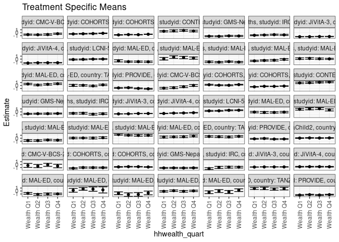

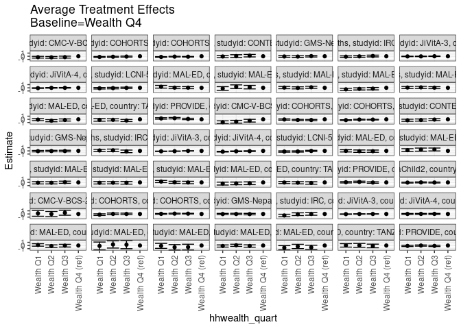

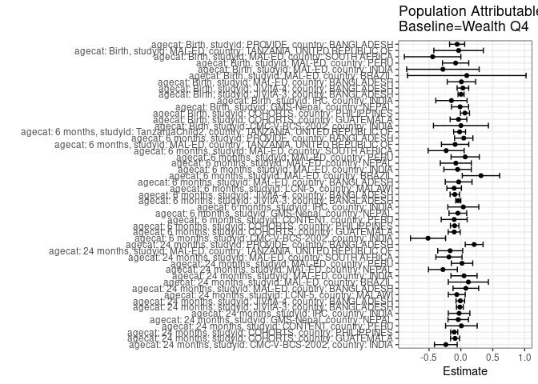

## Results Table

### Parameter: TSM

| agecat | studyid | country | intervention_level | baseline_level | estimate | ci_lower | ci_upper |
| --- | --- | --- | --- | --- | --- | --- | --- |
| Birth | CMC-V-BCS-2002 | INDIA | Wealth Q4 | NA | -0.4656878 | -1.0672916 | 0.1359159 |
| Birth | CMC-V-BCS-2002 | INDIA | Wealth Q1 | NA | -0.2772346 | -0.9607476 | 0.4062784 |
| Birth | CMC-V-BCS-2002 | INDIA | Wealth Q2 | NA | -0.4878171 | -1.0319524 | 0.0563183 |
| Birth | CMC-V-BCS-2002 | INDIA | Wealth Q3 | NA | -0.0747761 | -0.5932283 | 0.4436760 |
| Birth | COHORTS | GUATEMALA | Wealth Q4 | NA | -1.0197537 | -1.1944610 | -0.8450465 |
| Birth | COHORTS | GUATEMALA | Wealth Q1 | NA | -1.2383507 | -1.4359722 | -1.0407292 |
| Birth | COHORTS | GUATEMALA | Wealth Q2 | NA | -0.9945082 | -1.2049419 | -0.7840745 |
| Birth | COHORTS | GUATEMALA | Wealth Q3 | NA | -1.0116901 | -1.2121635 | -0.8112167 |
| Birth | COHORTS | PHILIPPINES | Wealth Q4 | NA | -0.8061435 | -0.8908005 | -0.7214866 |
| Birth | COHORTS | PHILIPPINES | Wealth Q1 | NA | -0.7718062 | -0.8717489 | -0.6718635 |
| Birth | COHORTS | PHILIPPINES | Wealth Q2 | NA | -0.6984784 | -0.8062604 | -0.5906965 |
| Birth | COHORTS | PHILIPPINES | Wealth Q3 | NA | -0.7106961 | -0.7901245 | -0.6312677 |
| Birth | GMS-Nepal | NEPAL | Wealth Q4 | NA | -1.1033142 | -1.2604557 | -0.9461728 |
| Birth | GMS-Nepal | NEPAL | Wealth Q1 | NA | -1.1293362 | -1.2842439 | -0.9744285 |
| Birth | GMS-Nepal | NEPAL | Wealth Q2 | NA | -1.1102951 | -1.2750019 | -0.9455882 |
| Birth | GMS-Nepal | NEPAL | Wealth Q3 | NA | -1.1379460 | -1.3147048 | -0.9611872 |
| Birth | IRC | INDIA | Wealth Q4 | NA | -0.8620998 | -1.1409076 | -0.5832920 |
| Birth | IRC | INDIA | Wealth Q1 | NA | -1.3432213 | -1.6571809 | -1.0292617 |
| Birth | IRC | INDIA | Wealth Q2 | NA | -0.9359299 | -1.3004806 | -0.5713793 |
| Birth | IRC | INDIA | Wealth Q3 | NA | -0.8582629 | -1.1865840 | -0.5299417 |
| Birth | JiVitA-3 | BANGLADESH | Wealth Q4 | NA | -0.7805050 | -0.8331197 | -0.7278904 |
| Birth | JiVitA-3 | BANGLADESH | Wealth Q1 | NA | -0.8252349 | -0.8658207 | -0.7846492 |
| Birth | JiVitA-3 | BANGLADESH | Wealth Q2 | NA | -0.7824106 | -0.8183676 | -0.7464536 |
| Birth | JiVitA-3 | BANGLADESH | Wealth Q3 | NA | -0.7795197 | -0.8124159 | -0.7466236 |
| Birth | JiVitA-4 | BANGLADESH | Wealth Q4 | NA | -0.7201226 | -0.8221779 | -0.6180672 |
| Birth | JiVitA-4 | BANGLADESH | Wealth Q1 | NA | -0.7101528 | -0.8265815 | -0.5937241 |
| Birth | JiVitA-4 | BANGLADESH | Wealth Q2 | NA | -0.6985047 | -0.8124009 | -0.5846086 |
| Birth | JiVitA-4 | BANGLADESH | Wealth Q3 | NA | -0.6948592 | -0.8207532 | -0.5689651 |
| Birth | MAL-ED | BANGLADESH | Wealth Q4 | NA | -0.9810121 | -1.2254444 | -0.7365797 |
| Birth | MAL-ED | BANGLADESH | Wealth Q1 | NA | -0.8004705 | -1.1047683 | -0.4961727 |

[output cut: 166 more lines]

### Parameter: E(Y)

| agecat | studyid | country | intervention_level | baseline_level | estimate | ci_lower | ci_upper |
| --- | --- | --- | --- | --- | --- | --- | --- |
| Birth | CMC-V-BCS-2002 | INDIA | NA | NA | -0.4648256 | -0.7643210 | -0.1653302 |
| Birth | COHORTS | GUATEMALA | NA | NA | -1.0572840 | -1.1606089 | -0.9539590 |
| Birth | COHORTS | PHILIPPINES | NA | NA | -0.7422912 | -0.7886598 | -0.6959226 |
| Birth | GMS-Nepal | NEPAL | NA | NA | -1.1164431 | -1.2040134 | -1.0288728 |
| Birth | IRC | INDIA | NA | NA | -1.0105831 | -1.1973019 | -0.8238643 |
| Birth | JiVitA-3 | BANGLADESH | NA | NA | -0.7777103 | -0.7967006 | -0.7587201 |
| Birth | JiVitA-4 | BANGLADESH | NA | NA | -0.6882498 | -0.7406539 | -0.6358456 |
| Birth | MAL-ED | BANGLADESH | NA | NA | -0.9728358 | -1.1217009 | -0.8239707 |
| Birth | MAL-ED | BRAZIL | NA | NA | 0.4643860 | 0.1360519 | 0.7927200 |
| Birth | MAL-ED | INDIA | NA | NA | -0.9441026 | -1.2397919 | -0.6484132 |
| Birth | MAL-ED | PERU | NA | NA | -0.0468095 | -0.1738806 | 0.0802616 |
| Birth | MAL-ED | SOUTH AFRICA | NA | NA | -0.1729474 | -0.4186222 | 0.0727275 |
| Birth | MAL-ED | TANZANIA, UNITED REPUBLIC OF | NA | NA | 0.7637500 | 0.5676177 | 0.9598823 |
| Birth | PROVIDE | BANGLADESH | NA | NA | -1.2984586 | -1.3752758 | -1.2216415 |
| 6 months | CMC-V-BCS-2002 | INDIA | NA | NA | -0.5026766 | -0.6536848 | -0.3516685 |
| 6 months | COHORTS | GUATEMALA | NA | NA | 0.1914471 | 0.1185005 | 0.2643936 |
| 6 months | COHORTS | PHILIPPINES | NA | NA | -0.2938433 | -0.3352064 | -0.2524802 |
| 6 months | CONTENT | PERU | NA | NA | 1.0644279 | 0.9468682 | 1.1819876 |
| 6 months | GMS-Nepal | NEPAL | NA | NA | -0.6038416 | -0.6899448 | -0.5177384 |
| 6 months | IRC | INDIA | NA | NA | -0.5989297 | -0.7344491 | -0.4634104 |
| 6 months | JiVitA-3 | BANGLADESH | NA | NA | -0.5932502 | -0.6127743 | -0.5737261 |
| 6 months | JiVitA-4 | BANGLADESH | NA | NA | -0.3901595 | -0.4274150 | -0.3529041 |
| 6 months | LCNI-5 | MALAWI | NA | NA | 0.4417647 | 0.3702742 | 0.5132552 |
| 6 months | MAL-ED | BANGLADESH | NA | NA | -0.1333333 | -0.2623761 | -0.0042906 |
| 6 months | MAL-ED | BRAZIL | NA | NA | 0.9720774 | 0.8078144 | 1.1363403 |
| 6 months | MAL-ED | INDIA | NA | NA | -0.7102872 | -0.8371659 | -0.5834085 |
| 6 months | MAL-ED | NEPAL | NA | NA | 0.1104308 | -0.0208643 | 0.2417259 |
| 6 months | MAL-ED | PERU | NA | NA | 1.0512099 | 0.9285617 | 1.1738581 |
| 6 months | MAL-ED | SOUTH AFRICA | NA | NA | 0.5404351 | 0.3867005 | 0.6941696 |
| 6 months | MAL-ED | TANZANIA, UNITED REPUBLIC OF | NA | NA | 0.5362213 | 0.4049390 | 0.6675036 |
| 6 months | PROVIDE | BANGLADESH | NA | NA | -0.1990907 | -0.2817968 | -0.1163845 |
| 6 months | TanzaniaChild2 | TANZANIA, UNITED REPUBLIC OF | NA | NA | 0.0801680 | 0.0273223 | 0.1330136 |
| 24 months | CMC-V-BCS-2002 | INDIA | NA | NA | -0.5571505 | -0.6585247 | -0.4557763 |
| 24 months | COHORTS | GUATEMALA | NA | NA | -0.2791396 | -0.3336899 | -0.2245893 |
| 24 months | COHORTS | PHILIPPINES | NA | NA | -0.6099592 | -0.6467541 | -0.5731643 |
| 24 months | CONTENT | PERU | NA | NA | 0.5902439 | 0.4560143 | 0.7244735 |
| 24 months | GMS-Nepal | NEPAL | NA | NA | -1.1363107 | -1.2252817 | -1.0473398 |
| 24 months | IRC | INDIA | NA | NA | -0.7458150 | -0.8368180 | -0.6548120 |
| 24 months | JiVitA-3 | BANGLADESH | NA | NA | -1.2973086 | -1.3206115 | -1.2740057 |
| 24 months | JiVitA-4 | BANGLADESH | NA | NA | -1.2231776 | -1.2550332 | -1.1913220 |
| 24 months | LCNI-5 | MALAWI | NA | NA | -0.0477867 | -0.1301103 | 0.0345368 |
| 24 months | MAL-ED | BANGLADESH | NA | NA | -0.8192925 | -0.9412667 | -0.6973182 |
| 24 months | MAL-ED | BRAZIL | NA | NA | 0.4626233 | 0.2567495 | 0.6684971 |
| 24 months | MAL-ED | INDIA | NA | NA | -0.9516520 | -1.0670654 | -0.8362385 |
| 24 months | MAL-ED | NEPAL | NA | NA | -0.3749123 | -0.4886073 | -0.2612173 |
| 24 months | MAL-ED | PERU | NA | NA | 0.1111982 | -0.0118399 | 0.2342362 |
| 24 months | MAL-ED | SOUTH AFRICA | NA | NA | 0.4090301 | 0.2879441 | 0.5301161 |
| 24 months | MAL-ED | TANZANIA, UNITED REPUBLIC OF | NA | NA | 0.0547975 | -0.0703378 | 0.1799328 |
| 24 months | PROVIDE | BANGLADESH | NA | NA | -0.8928670 | -0.9755153 | -0.8102187 |

### Parameter: ATE

| agecat | studyid | country | intervention_level | baseline_level | estimate | ci_lower | ci_upper |
| --- | --- | --- | --- | --- | --- | --- | --- |
| Birth | CMC-V-BCS-2002 | INDIA | Wealth Q4 | Wealth Q4 | 0.0000000 | 0.0000000 | 0.0000000 |
| Birth | CMC-V-BCS-2002 | INDIA | Wealth Q1 | Wealth Q4 | 0.1884533 | -0.7205283 | 1.0974348 |
| Birth | CMC-V-BCS-2002 | INDIA | Wealth Q2 | Wealth Q4 | -0.0221292 | -0.8373733 | 0.7931148 |
| Birth | CMC-V-BCS-2002 | INDIA | Wealth Q3 | Wealth Q4 | 0.3909117 | -0.4063840 | 1.1882075 |
| Birth | COHORTS | GUATEMALA | Wealth Q4 | Wealth Q4 | 0.0000000 | 0.0000000 | 0.0000000 |
| Birth | COHORTS | GUATEMALA | Wealth Q1 | Wealth Q4 | -0.2185970 | -0.4739813 | 0.0367874 |
| Birth | COHORTS | GUATEMALA | Wealth Q2 | Wealth Q4 | 0.0252455 | -0.2400514 | 0.2905424 |
| Birth | COHORTS | GUATEMALA | Wealth Q3 | Wealth Q4 | 0.0080636 | -0.2484847 | 0.2646120 |
| Birth | COHORTS | PHILIPPINES | Wealth Q4 | Wealth Q4 | 0.0000000 | 0.0000000 | 0.0000000 |
| Birth | COHORTS | PHILIPPINES | Wealth Q1 | Wealth Q4 | 0.0343373 | -0.0947188 | 0.1633935 |
| Birth | COHORTS | PHILIPPINES | Wealth Q2 | Wealth Q4 | 0.1076651 | -0.0276419 | 0.2429721 |
| Birth | COHORTS | PHILIPPINES | Wealth Q3 | Wealth Q4 | 0.0954474 | -0.0185149 | 0.2094097 |
| Birth | GMS-Nepal | NEPAL | Wealth Q4 | Wealth Q4 | 0.0000000 | 0.0000000 | 0.0000000 |
| Birth | GMS-Nepal | NEPAL | Wealth Q1 | Wealth Q4 | -0.0260220 | -0.2397307 | 0.1876868 |
| Birth | GMS-Nepal | NEPAL | Wealth Q2 | Wealth Q4 | -0.0069808 | -0.2275284 | 0.2135668 |
| Birth | GMS-Nepal | NEPAL | Wealth Q3 | Wealth Q4 | -0.0346318 | -0.2643138 | 0.1950503 |
| Birth | IRC | INDIA | Wealth Q4 | Wealth Q4 | 0.0000000 | 0.0000000 | 0.0000000 |
| Birth | IRC | INDIA | Wealth Q1 | Wealth Q4 | -0.4811215 | -0.8779922 | -0.0842507 |
| Birth | IRC | INDIA | Wealth Q2 | Wealth Q4 | -0.0738301 | -0.5086379 | 0.3609777 |
| Birth | IRC | INDIA | Wealth Q3 | Wealth Q4 | 0.0038370 | -0.4008052 | 0.4084791 |
| Birth | JiVitA-3 | BANGLADESH | Wealth Q4 | Wealth Q4 | 0.0000000 | 0.0000000 | 0.0000000 |
| Birth | JiVitA-3 | BANGLADESH | Wealth Q1 | Wealth Q4 | -0.0447299 | -0.1073319 | 0.0178721 |
| Birth | JiVitA-3 | BANGLADESH | Wealth Q2 | Wealth Q4 | -0.0019056 | -0.0635818 | 0.0597707 |
| Birth | JiVitA-3 | BANGLADESH | Wealth Q3 | Wealth Q4 | 0.0009853 | -0.0578484 | 0.0598190 |
| Birth | JiVitA-4 | BANGLADESH | Wealth Q4 | Wealth Q4 | 0.0000000 | 0.0000000 | 0.0000000 |
| Birth | JiVitA-4 | BANGLADESH | Wealth Q1 | Wealth Q4 | 0.0099698 | -0.1418789 | 0.1618185 |
| Birth | JiVitA-4 | BANGLADESH | Wealth Q2 | Wealth Q4 | 0.0216178 | -0.1303213 | 0.1735569 |
| Birth | JiVitA-4 | BANGLADESH | Wealth Q3 | Wealth Q4 | 0.0252634 | -0.1353175 | 0.1858443 |
| Birth | MAL-ED | BANGLADESH | Wealth Q4 | Wealth Q4 | 0.0000000 | 0.0000000 | 0.0000000 |
| Birth | MAL-ED | BANGLADESH | Wealth Q1 | Wealth Q4 | 0.1805416 | -0.2107217 | 0.5718049 |

[output cut: 166 more lines]

### Parameter: PAR

| agecat | studyid | country | intervention_level | baseline_level | estimate | ci_lower | ci_upper |
| --- | --- | --- | --- | --- | --- | --- | --- |
| Birth | CMC-V-BCS-2002 | INDIA | Wealth Q4 | NA | 0.0008623 | -0.4300990 | 0.4318235 |
| Birth | COHORTS | GUATEMALA | Wealth Q4 | NA | -0.0375302 | -0.1681602 | 0.0930997 |
| Birth | COHORTS | PHILIPPINES | Wealth Q4 | NA | 0.0638523 | -0.0070274 | 0.1347321 |
| Birth | GMS-Nepal | NEPAL | Wealth Q4 | NA | -0.0131288 | -0.1474298 | 0.1211722 |
| Birth | IRC | INDIA | Wealth Q4 | NA | -0.1484832 | -0.3941580 | 0.0971915 |
| Birth | JiVitA-3 | BANGLADESH | Wealth Q4 | NA | 0.0027947 | -0.0445207 | 0.0501101 |
| Birth | JiVitA-4 | BANGLADESH | Wealth Q4 | NA | 0.0318728 | -0.0589249 | 0.1226704 |
| Birth | MAL-ED | BANGLADESH | Wealth Q4 | NA | 0.0081762 | -0.2140398 | 0.2303923 |
| Birth | MAL-ED | BRAZIL | Wealth Q4 | NA | 0.0919507 | -0.8383430 | 1.0222444 |
| Birth | MAL-ED | INDIA | Wealth Q4 | NA | -0.2816026 | -0.8500282 | 0.2868230 |
| Birth | MAL-ED | PERU | Wealth Q4 | NA | -0.0826501 | -0.2888972 | 0.1235971 |
| Birth | MAL-ED | SOUTH AFRICA | Wealth Q4 | NA | -0.4431464 | -0.8856929 | -0.0005998 |
| Birth | MAL-ED | TANZANIA, UNITED REPUBLIC OF | Wealth Q4 | NA | -0.0357757 | -0.4240737 | 0.3525222 |
| Birth | PROVIDE | BANGLADESH | Wealth Q4 | NA | -0.0587353 | -0.1771043 | 0.0596337 |
| 6 months | CMC-V-BCS-2002 | INDIA | Wealth Q4 | NA | -0.5151356 | -0.7905315 | -0.2397398 |
| 6 months | COHORTS | GUATEMALA | Wealth Q4 | NA | -0.1047677 | -0.1989886 | -0.0105468 |
| 6 months | COHORTS | PHILIPPINES | Wealth Q4 | NA | -0.0980031 | -0.1647563 | -0.0312498 |
| 6 months | CONTENT | PERU | Wealth Q4 | NA | -0.1049108 | -0.3083643 | 0.0985428 |
| 6 months | GMS-Nepal | NEPAL | Wealth Q4 | NA | -0.0474447 | -0.1857661 | 0.0908766 |
| 6 months | IRC | INDIA | Wealth Q4 | NA | 0.0383064 | -0.2045053 | 0.2811180 |
| 6 months | JiVitA-3 | BANGLADESH | Wealth Q4 | NA | -0.0411085 | -0.0806971 | -0.0015200 |
| 6 months | JiVitA-4 | BANGLADESH | Wealth Q4 | NA | -0.0956315 | -0.1690264 | -0.0222366 |
| 6 months | LCNI-5 | MALAWI | Wealth Q4 | NA | -0.1054205 | -0.2196642 | 0.0088231 |
| 6 months | MAL-ED | BANGLADESH | Wealth Q4 | NA | -0.0350048 | -0.2445852 | 0.1745755 |
| 6 months | MAL-ED | BRAZIL | Wealth Q4 | NA | 0.3153756 | 0.0219637 | 0.6087876 |
| 6 months | MAL-ED | INDIA | Wealth Q4 | NA | -0.0516402 | -0.2667889 | 0.1635085 |
| 6 months | MAL-ED | NEPAL | Wealth Q4 | NA | -0.0790327 | -0.3221358 | 0.1640704 |
| 6 months | MAL-ED | PERU | Wealth Q4 | NA | 0.0677458 | -0.1534494 | 0.2889409 |
| 6 months | MAL-ED | SOUTH AFRICA | Wealth Q4 | NA | -0.2311275 | -0.5135480 | 0.0512931 |
| 6 months | MAL-ED | TANZANIA, UNITED REPUBLIC OF | Wealth Q4 | NA | -0.0906464 | -0.3048249 | 0.1235322 |
| 6 months | PROVIDE | BANGLADESH | Wealth Q4 | NA | 0.0447283 | -0.0993756 | 0.1888322 |
| 6 months | TanzaniaChild2 | TANZANIA, UNITED REPUBLIC OF | Wealth Q4 | NA | -0.0200254 | -0.1133384 | 0.0732876 |
| 24 months | CMC-V-BCS-2002 | INDIA | Wealth Q4 | NA | -0.2363913 | -0.4146184 | -0.0581642 |
| 24 months | COHORTS | GUATEMALA | Wealth Q4 | NA | -0.0913312 | -0.1616884 | -0.0209740 |
| 24 months | COHORTS | PHILIPPINES | Wealth Q4 | NA | -0.1046726 | -0.1607504 | -0.0485948 |
| 24 months | CONTENT | PERU | Wealth Q4 | NA | 0.0080306 | -0.2400053 | 0.2560664 |
| 24 months | GMS-Nepal | NEPAL | Wealth Q4 | NA | -0.0414940 | -0.2020077 | 0.1190198 |
| 24 months | IRC | INDIA | Wealth Q4 | NA | -0.0282754 | -0.1973173 | 0.1407664 |
| 24 months | JiVitA-3 | BANGLADESH | Wealth Q4 | NA | -0.0161490 | -0.0692217 | 0.0369237 |
| 24 months | JiVitA-4 | BANGLADESH | Wealth Q4 | NA | -0.0088014 | -0.0760634 | 0.0584607 |
| 24 months | LCNI-5 | MALAWI | Wealth Q4 | NA | -0.0645757 | -0.1967315 | 0.0675801 |
| 24 months | MAL-ED | BANGLADESH | Wealth Q4 | NA | 0.0780594 | -0.1228489 | 0.2789677 |
| 24 months | MAL-ED | BRAZIL | Wealth Q4 | NA | 0.1170493 | -0.1973237 | 0.4314224 |
| 24 months | MAL-ED | INDIA | Wealth Q4 | NA | 0.0492162 | -0.1559009 | 0.2543333 |
| 24 months | MAL-ED | NEPAL | Wealth Q4 | NA | -0.2814228 | -0.5077350 | -0.0551106 |
| 24 months | MAL-ED | PERU | Wealth Q4 | NA | 0.0181836 | -0.1501299 | 0.1864971 |
| 24 months | MAL-ED | SOUTH AFRICA | Wealth Q4 | NA | -0.1869976 | -0.3921308 | 0.0181355 |
| 24 months | MAL-ED | TANZANIA, UNITED REPUBLIC OF | Wealth Q4 | NA | -0.1677953 | -0.3638425 | 0.0282519 |
| 24 months | PROVIDE | BANGLADESH | Wealth Q4 | NA | 0.2082435 | 0.0682239 | 0.3482630 |